# Final_Dissertation_Patient Survival Prediction

```python
pip install imbalanced-learn
```

```python
pip install category_encoders
```

```python
pip install xgboost
```

```python
pip install scikit-plot
```

```python
import category_encoders as ce
import imblearn.combine as hib
import imblearn.over_sampling as os
import imblearn.under_sampling as us
import matplotlib.pyplot as plt
import numpy as np
import pandas as pd
import scikitplot as skplt
import seaborn as sns
import shap
import time
import warnings
warnings.filterwarnings('ignore')

from collections import Counter
from imblearn.metrics import geometric_mean_score
from imblearn.pipeline import make_pipeline
from imblearn.over_sampling import SMOTE
from imblearn.under_sampling import AllKNN
from imblearn.under_sampling import CondensedNearestNeighbour
from imblearn.under_sampling import EditedNearestNeighbours
from imblearn.under_sampling import NeighbourhoodCleaningRule
from imblearn.under_sampling import OneSidedSelection
from imblearn.under_sampling import TomekLinks


from sklearn import feature_selection
from sklearn import model_selection
from sklearn import neighbors
from sklearn import preprocessing
from sklearn import set_config

from sklearn.base import BaseEstimator, TransformerMixin
from sklearn.compose import ColumnTransformer
from sklearn.decomposition import PCA
from sklearn.ensemble import GradientBoostingClassifier
from sklearn.ensemble import RandomForestClassifier
from sklearn.impute import KNNImputer
from sklearn.impute import SimpleImputer
from sklearn.linear_model import LogisticRegression
from sklearn.metrics import accuracy_score, precision_score, recall_score, f1_score
from sklearn.metrics import mean_absolute_error, mean_squared_error, r2_score
from sklearn.metrics import roc_curve, auc, average_precision_score, precision_recall_curve, confusion_matrix
from sklearn.metrics import fbeta_score, make_scorer
from sklearn.model_selection import GridSearchCV
from sklearn.model_selection import StratifiedKFold
from sklearn.model_selection import train_test_split

from sklearn.pipeline import Pipeline
from sklearn.preprocessing import LabelEncoder
from sklearn.preprocessing import OneHotEncoder
from sklearn.preprocessing import StandardScaler
from sklearn.tree import DecisionTreeClassifier
from sklearn.svm import SVC
from xgboost import XGBClassifier
```

```python
# Loading the dataset from the given path into a DataFrame
df = pd.read_csv('/Users/hung1/Desktop/Patient_Mortality_Prediction.csv')
```

```python
# Displaying the first 10 rows of the dataframe for a quick glance
df.head(10)
```

|  | encounter_id | patient_id | hospital_id | age | bmi | elective_surgery | ethnicity | gender | height | icu_admit_source | ... | diabetes_mellitus | hepatic_failure | immunosuppression | leukemia | lymphoma | solid_tumor_with_metastasis | apache_3j_bodysystem | apache_2_bodysystem | Unnamed: 83 | hospital_death |
| --- | --- | --- | --- | --- | --- | --- | --- | --- | --- | --- | --- | --- | --- | --- | --- | --- | --- | --- | --- | --- | --- |
| 0 | 66154 | 25312 | 118 | 68.0 | 22.73 | 0 | Caucasian | M | 180.3 | Floor | ... | 1.0 | 0.0 | 0.0 | 0.0 | 0.0 | 0.0 | Sepsis | Cardiovascular | NaN | 0 |
| 1 | 114252 | 59342 | 81 | 77.0 | 27.42 | 0 | Caucasian | F | 160.0 | Floor | ... | 1.0 | 0.0 | 0.0 | 0.0 | 0.0 | 0.0 | Respiratory | Respiratory | NaN | 0 |
| 2 | 119783 | 50777 | 118 | 25.0 | 31.95 | 0 | Caucasian | F | 172.7 | Accident & Emergency | ... | 0.0 | 0.0 | 0.0 | 0.0 | 0.0 | 0.0 | Metabolic | Metabolic | NaN | 0 |
| 3 | 79267 | 46918 | 118 | 81.0 | 22.64 | 1 | Caucasian | F | 165.1 | Operating Room / Recovery | ... | 0.0 | 0.0 | 0.0 | 0.0 | 0.0 | 0.0 | Cardiovascular | Cardiovascular | NaN | 0 |
| 4 | 92056 | 34377 | 33 | 19.0 | NaN | 0 | Caucasian | M | 188.0 | Accident & Emergency | ... | 0.0 | 0.0 | 0.0 | 0.0 | 0.0 | 0.0 | Trauma | Trauma | NaN | 0 |
| 5 | 33181 | 74489 | 83 | 67.0 | 27.56 | 0 | Caucasian | M | 190.5 | Accident & Emergency | ... | 1.0 | 0.0 | 0.0 | 0.0 | 0.0 | 0.0 | Neurological | Neurologic | NaN | 0 |
| 6 | 82208 | 49526 | 83 | 59.0 | 57.45 | 0 | Caucasian | F | 165.1 | Accident & Emergency | ... | 1.0 | 0.0 | 0.0 | 0.0 | 0.0 | 0.0 | Respiratory | Respiratory | NaN | 0 |
| 7 | 120995 | 50129 | 33 | 70.0 | NaN | 0 | Caucasian | M | 165.0 | Accident & Emergency | ... | 0.0 | 0.0 | 1.0 | 0.0 | 0.0 | 0.0 | Sepsis | Cardiovascular | NaN | 0 |
| 8 | 80471 | 10577 | 118 | 45.0 | NaN | 0 | Caucasian | M | 170.2 | Other Hospital | ... | 0.0 | 0.0 | 0.0 | 0.0 | 0.0 | 0.0 | Cardiovascular | Cardiovascular | NaN | 1 |
| 9 | 42871 | 90749 | 118 | 50.0 | 25.71 | 0 | NaN | M | 175.3 | Accident & Emergency | ... | 0.0 | 0.0 | 0.0 | 0.0 | 0.0 | 0.0 | Cardiovascular | Cardiovascular | NaN | 0 |

10 rows × 85 columns

```python
# Displaying the last 10 rows of the dataframe for a quick glance
df.tail(10)
```

|  | encounter_id | patient_id | hospital_id | age | bmi | elective_surgery | ethnicity | gender | height | icu_admit_source | ... | diabetes_mellitus | hepatic_failure | immunosuppression | leukemia | lymphoma | solid_tumor_with_metastasis | apache_3j_bodysystem | apache_2_bodysystem | Unnamed: 83 | hospital_death |
| --- | --- | --- | --- | --- | --- | --- | --- | --- | --- | --- | --- | --- | --- | --- | --- | --- | --- | --- | --- | --- | --- |
| 91703 | 65539 | 128056 | 30 | 53.0 | 45.935203 | 0 | Caucasian | M | 190.5 | Accident & Emergency | ... | 1.0 | 0.0 | 0.0 | 0.0 | 0.0 | 0.0 | Sepsis | Cardiovascular | NaN | 0 |
| 91704 | 96325 | 77671 | 30 | 38.0 | 32.992923 | 0 | Caucasian | M | 177.8 | Accident & Emergency | ... | 0.0 | 0.0 | 0.0 | 0.0 | 0.0 | 0.0 | Metabolic | Metabolic | NaN | 0 |
| 91705 | 111411 | 7848 | 195 | 67.0 | 28.876843 | 0 | African American | M | 182.9 | Accident & Emergency | ... | 1.0 | 0.0 | 0.0 | 0.0 | 0.0 | 0.0 | Metabolic | Metabolic | NaN | 0 |
| 91706 | 127138 | 59223 | 121 | 54.0 | 19.770448 | 0 | Native American | M | 177.8 | Accident & Emergency | ... | 0.0 | 0.0 | 0.0 | 0.0 | 0.0 | 0.0 | Cardiovascular | Cardiovascular | NaN | 0 |
| 91707 | 276 | 34638 | 183 | NaN | 33.933518 | 0 | Caucasian | F | 152.0 | Accident & Emergency | ... | NaN | NaN | NaN | NaN | NaN | NaN | NaN | NaN | NaN | 0 |
| 91708 | 91592 | 78108 | 30 | 75.0 | 23.060250 | 0 | Caucasian | M | 177.8 | Floor | ... | 1.0 | 0.0 | 0.0 | 0.0 | 0.0 | 1.0 | Sepsis | Cardiovascular | NaN | 0 |
| 91709 | 66119 | 13486 | 121 | 56.0 | 47.179671 | 0 | Caucasian | F | 183.0 | Floor | ... | 0.0 | 0.0 | 0.0 | 0.0 | 0.0 | 0.0 | Sepsis | Cardiovascular | NaN | 0 |
| 91710 | 8981 | 58179 | 195 | 48.0 | 27.236914 | 0 | Caucasian | M | 170.2 | Accident & Emergency | ... | 1.0 | 0.0 | 0.0 | 0.0 | 0.0 | 0.0 | Metabolic | Metabolic | NaN | 0 |
| 91711 | 33776 | 120598 | 66 | NaN | 23.297481 | 0 | Caucasian | F | 154.9 | Accident & Emergency | ... | 0.0 | 0.0 | 0.0 | 0.0 | 0.0 | 0.0 | Respiratory | Respiratory | NaN | 0 |
| 91712 | 1671 | 53612 | 104 | 82.0 | 22.031250 | 1 | Caucasian | F | 160.0 | Operating Room / Recovery | ... | 0.0 | 0.0 | 0.0 | 0.0 | 0.0 | 0.0 | Gastrointestinal | Gastrointestinal | NaN | 0 |

10 rows × 85 columns

Data overview

```python
# Displaying the general information about the DataFrame, including:
# the number of non-null values in each column, data type of each column, memory usage, etc.
df.info()
```

```
<class 'pandas.core.frame.DataFrame'>
RangeIndex: 91713 entries, 0 to 91712
Data columns (total 85 columns):
 #   Column                         Non-Null Count  Dtype
---  ------                         --------------  -----
 0   encounter_id                   91713 non-null  int64
 1   patient_id                     91713 non-null  int64
 2   hospital_id                    91713 non-null  int64
 3   age                            87485 non-null  float64
 4   bmi                            88284 non-null  float64
 5   elective_surgery               91713 non-null  int64
 6   ethnicity                      90318 non-null  object
 7   gender                         91688 non-null  object
 8   height                         90379 non-null  float64
 9   icu_admit_source               91601 non-null  object
```

[output cut: 77 more lines]

```python
# Displaying the summary statistics of the DataFrame's columns.
# This includes count, mean, std deviation, min value, 25th percentile, median, 75th percentile, and max value.
df.describe()
```

|  | encounter_id | patient_id | hospital_id | age | bmi | elective_surgery | height | icu_id | pre_icu_los_days | weight | ... | aids | cirrhosis | diabetes_mellitus | hepatic_failure | immunosuppression | leukemia | lymphoma | solid_tumor_with_metastasis | Unnamed: 83 | hospital_death |
| --- | --- | --- | --- | --- | --- | --- | --- | --- | --- | --- | --- | --- | --- | --- | --- | --- | --- | --- | --- | --- | --- |
| count | 91713.000000 | 91713.000000 | 91713.000000 | 87485.000000 | 88284.000000 | 91713.000000 | 90379.000000 | 91713.000000 | 91713.000000 | 88993.000000 | ... | 90998.000000 | 90998.000000 | 90998.000000 | 90998.000000 | 90998.000000 | 90998.000000 | 90998.000000 | 90998.000000 | 0.0 | 91713.000000 |
| mean | 65606.079280 | 65537.131464 | 105.669262 | 62.309516 | 29.185818 | 0.183736 | 169.641588 | 508.357692 | 0.835766 | 84.028340 | ... | 0.000857 | 0.015693 | 0.225192 | 0.012989 | 0.026165 | 0.007066 | 0.004132 | 0.020638 | NaN | 0.086302 |
| std | 37795.088538 | 37811.252183 | 62.854406 | 16.775119 | 8.275142 | 0.387271 | 10.795378 | 228.989661 | 2.487756 | 25.011497 | ... | 0.029265 | 0.124284 | 0.417711 | 0.113229 | 0.159628 | 0.083763 | 0.064148 | 0.142169 | NaN | 0.280811 |
| min | 1.000000 | 1.000000 | 2.000000 | 16.000000 | 14.844926 | 0.000000 | 137.200000 | 82.000000 | -24.947222 | 38.600000 | ... | 0.000000 | 0.000000 | 0.000000 | 0.000000 | 0.000000 | 0.000000 | 0.000000 | 0.000000 | NaN | 0.000000 |
| 25% | 32852.000000 | 32830.000000 | 47.000000 | 52.000000 | 23.641975 | 0.000000 | 162.500000 | 369.000000 | 0.035417 | 66.800000 | ... | 0.000000 | 0.000000 | 0.000000 | 0.000000 | 0.000000 | 0.000000 | 0.000000 | 0.000000 | NaN | 0.000000 |
| 50% | 65665.000000 | 65413.000000 | 109.000000 | 65.000000 | 27.654655 | 0.000000 | 170.100000 | 504.000000 | 0.138889 | 80.300000 | ... | 0.000000 | 0.000000 | 0.000000 | 0.000000 | 0.000000 | 0.000000 | 0.000000 | 0.000000 | NaN | 0.000000 |
| 75% | 98342.000000 | 98298.000000 | 161.000000 | 75.000000 | 32.930206 | 0.000000 | 177.800000 | 679.000000 | 0.409028 | 97.100000 | ... | 0.000000 | 0.000000 | 0.000000 | 0.000000 | 0.000000 | 0.000000 | 0.000000 | 0.000000 | NaN | 0.000000 |
| max | 131051.000000 | 131051.000000 | 204.000000 | 89.000000 | 67.814990 | 1.000000 | 195.590000 | 927.000000 | 159.090972 | 186.000000 | ... | 1.000000 | 1.000000 | 1.000000 | 1.000000 | 1.000000 | 1.000000 | 1.000000 | 1.000000 | NaN | 1.000000 |

8 rows × 78 columns

```python
# Calculating and displaying the number of missing values in each column of the DataFrame.
df.isnull().sum()
```

```
encounter_id                       0
patient_id                         0
hospital_id                        0
age                             4228
bmi                             3429
                               ...
solid_tumor_with_metastasis      715
apache_3j_bodysystem            1662
apache_2_bodysystem             1662
Unnamed: 83                    91713
hospital_death                     0
Length: 85, dtype: int64
```

Data Preprocessing

1. Elimination of redundant attributes

```python
# Define the target variable
df_output = 'hospital_death'

# Dropping unnecessary columns from the DataFrame
# 'Unnamed: 83' seems to be a redundant column, often generated during CSV export
# 'encounter_id' and 'hospital_id' are identifiers which might not be needed for analysis
df.drop(['Unnamed: 83', 'encounter_id', 'hospital_id'], axis=1, inplace=True)

# Displaying the general information about the DataFrame:
# This provides details such as data type, non-null counts, and memory usage for each column
df.info()
```

```
<class 'pandas.core.frame.DataFrame'>
RangeIndex: 91713 entries, 0 to 91712
Data columns (total 82 columns):
 #   Column                         Non-Null Count  Dtype
---  ------                         --------------  -----
 0   patient_id                     91713 non-null  int64
 1   age                            87485 non-null  float64
 2   bmi                            88284 non-null  float64
 3   elective_surgery               91713 non-null  int64
 4   ethnicity                      90318 non-null  object
 5   gender                         91688 non-null  object
 6   height                         90379 non-null  float64
 7   icu_admit_source               91601 non-null  object
 8   icu_id                         91713 non-null  int64
 9   icu_stay_type                  91713 non-null  object
```

[output cut: 74 more lines]

```python
# Displaying the summary statistics of the DataFrame's columns
# This will give insights like count, mean, std deviation, min value, quartiles, and max value for each column
df.describe()
```

|  | patient_id | age | bmi | elective_surgery | height | icu_id | pre_icu_los_days | weight | apache_2_diagnosis | apache_3j_diagnosis | ... | apache_4a_icu_death_prob | aids | cirrhosis | diabetes_mellitus | hepatic_failure | immunosuppression | leukemia | lymphoma | solid_tumor_with_metastasis | hospital_death |
| --- | --- | --- | --- | --- | --- | --- | --- | --- | --- | --- | --- | --- | --- | --- | --- | --- | --- | --- | --- | --- | --- |
| count | 91713.000000 | 87485.000000 | 88284.000000 | 91713.000000 | 90379.000000 | 91713.000000 | 91713.000000 | 88993.000000 | 90051.000000 | 90612.000000 | ... | 83766.000000 | 90998.000000 | 90998.000000 | 90998.000000 | 90998.000000 | 90998.000000 | 90998.000000 | 90998.000000 | 90998.000000 | 91713.000000 |
| mean | 65537.131464 | 62.309516 | 29.185818 | 0.183736 | 169.641588 | 508.357692 | 0.835766 | 84.028340 | 185.401739 | 558.216377 | ... | 0.043955 | 0.000857 | 0.015693 | 0.225192 | 0.012989 | 0.026165 | 0.007066 | 0.004132 | 0.020638 | 0.086302 |
| std | 37811.252183 | 16.775119 | 8.275142 | 0.387271 | 10.795378 | 228.989661 | 2.487756 | 25.011497 | 86.050882 | 463.266985 | ... | 0.217341 | 0.029265 | 0.124284 | 0.417711 | 0.113229 | 0.159628 | 0.083763 | 0.064148 | 0.142169 | 0.280811 |
| min | 1.000000 | 16.000000 | 14.844926 | 0.000000 | 137.200000 | 82.000000 | -24.947222 | 38.600000 | 101.000000 | 0.010000 | ... | -1.000000 | 0.000000 | 0.000000 | 0.000000 | 0.000000 | 0.000000 | 0.000000 | 0.000000 | 0.000000 | 0.000000 |
| 25% | 32830.000000 | 52.000000 | 23.641975 | 0.000000 | 162.500000 | 369.000000 | 0.035417 | 66.800000 | 113.000000 | 203.010000 | ... | 0.010000 | 0.000000 | 0.000000 | 0.000000 | 0.000000 | 0.000000 | 0.000000 | 0.000000 | 0.000000 | 0.000000 |
| 50% | 65413.000000 | 65.000000 | 27.654655 | 0.000000 | 170.100000 | 504.000000 | 0.138889 | 80.300000 | 122.000000 | 409.020000 | ... | 0.020000 | 0.000000 | 0.000000 | 0.000000 | 0.000000 | 0.000000 | 0.000000 | 0.000000 | 0.000000 | 0.000000 |
| 75% | 98298.000000 | 75.000000 | 32.930206 | 0.000000 | 177.800000 | 679.000000 | 0.409028 | 97.100000 | 301.000000 | 703.030000 | ... | 0.060000 | 0.000000 | 0.000000 | 0.000000 | 0.000000 | 0.000000 | 0.000000 | 0.000000 | 0.000000 | 0.000000 |
| max | 131051.000000 | 89.000000 | 67.814990 | 1.000000 | 195.590000 | 927.000000 | 159.090972 | 186.000000 | 308.000000 | 2201.050000 | ... | 0.970000 | 1.000000 | 1.000000 | 1.000000 | 1.000000 | 1.000000 | 1.000000 | 1.000000 | 1.000000 | 1.000000 |

8 rows × 75 columns

```python
# Fetching and displaying rows with any missing values
# This helps in understanding which rows have missing data and may require imputation or deletion
missing_rows_df = df[df.isnull().any(axis=1)]
print(missing_rows_df)
```

```
       patient_id   age        bmi  elective_surgery         ethnicity gender  \
2           50777  25.0  31.950000                 0         Caucasian      F
3           46918  81.0  22.640000                 1         Caucasian      F
4           34377  19.0        NaN                 0         Caucasian      M
6           49526  59.0  57.450000                 0         Caucasian      F
7           50129  70.0        NaN                 0         Caucasian      M
...           ...   ...        ...               ...               ...    ...
91704       77671  38.0  32.992923                 0         Caucasian      M
91705        7848  67.0  28.876843                 0  African American      M
91707       34638   NaN  33.933518                 0         Caucasian      F
91710       58179  48.0  27.236914                 0         Caucasian      M
91711      120598   NaN  23.297481                 0         Caucasian      F

       height           icu_admit_source  icu_id icu_stay_type  ... cirrhosis  \
2       172.7       Accident & Emergency      93         admit  ...       0.0
```

[output cut: 51 more lines]

Data visualization

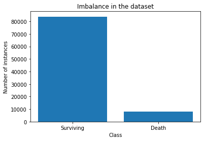

```python
# Getting the counts of each class in the target variable
counts = df[df_output].value_counts()

# Plotting the bar chart to visualize class distribution
plt.bar(counts.index, counts.values)

# Setting the x-ticks labels for better understanding
# Assuming 0 represents 'Surviving' and 1 represents 'Death' in the target variable
plt.xticks([0, 1], ['Surviving', 'Death'])

# Setting the label for the x-axis
plt.xlabel('Class')

# Setting the label for the y-axis
plt.ylabel('Number of instances')

# Setting the title for the plot to indicate we're checking imbalance
plt.title('Imbalance in the dataset')

# Displaying the plot
plt.show()
```

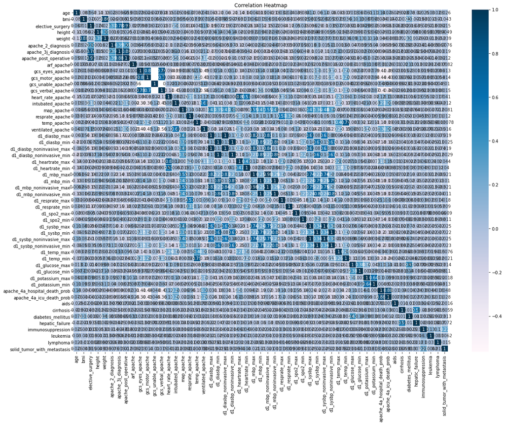

```python
# Specifying columns for which we want to visualize the correlations
category = [
    'age', 'bmi', 'elective_surgery', 'ethnicity', 'gender', 'height', 'weight', 'apache_2_diagnosis',
    'apache_3j_diagnosis', 'apache_post_operative', 'arf_apache', 'gcs_eyes_apache',
    'gcs_motor_apache', 'gcs_unable_apache', 'gcs_verbal_apache', 'heart_rate_apache',
    'intubated_apache', 'map_apache', 'resprate_apache', 'temp_apache', 'ventilated_apache',
    'd1_diasbp_max', 'd1_diasbp_min', 'd1_diasbp_noninvasive_max', 'd1_diasbp_noninvasive_min',
    'd1_heartrate_max', 'd1_heartrate_min', 'd1_mbp_max', 'd1_mbp_min', 'd1_mbp_noninvasive_max',
    'd1_mbp_noninvasive_min', 'd1_resprate_max', 'd1_resprate_min', 'd1_spo2_max', 'd1_spo2_min',
    'd1_sysbp_max', 'd1_sysbp_min', 'd1_sysbp_noninvasive_max', 'd1_sysbp_noninvasive_min',
    'd1_temp_max', 'd1_temp_min', 'd1_glucose_max', 'd1_glucose_min',
    'd1_potassium_max', 'd1_potassium_min', 'apache_4a_hospital_death_prob', 'apache_4a_icu_death_prob',
    'aids', 'cirrhosis', 'diabetes_mellitus', 'hepatic_failure', 'immunosuppression',
    'leukemia', 'lymphoma', 'solid_tumor_with_metastasis', 'apache_3j_bodysystem', 'apache_2_bodysystem'
]

# Compute the correlation matrix for the specified columns
corr = df[category].corr()

# Set up the figure and axis
plt.figure(figsize=(20,15))

# Display the heatmap of the correlation matrix
# Annotated with actual correlation values, using a blue color map
sns.heatmap(corr, annot=True, cmap='PuBu', linewidths=0.01, linecolor="white")

# Title for the heatmap
plt.title('Correlation Heatmap')

# Rotating x-axis labels for better visibility, keeping y-axis labels horizontal
plt.xticks(rotation=90)
plt.yticks(rotation=0)

# Display the plotted heatmap
plt.show()
```

```python
# Check and print the number of duplicate rows in the dataframe
duplicate_rows = df[df.duplicated()]
print("Number of duplicate rows:", duplicate_rows.shape[0])
```

```
Number of duplicate rows: 0
```

```python
# Display the count of different values in the 'hospital_death' column
print(Counter(df['hospital_death']))

# Group by 'patient_id' and keep the first occurrence. This helps in removing duplicates based on 'patient_id'
df = df.groupby('patient_id').first().reset_index()

# Drop the 'patient_id' column as it's no longer needed
df.drop(['patient_id'], axis=1, inplace=True)
```

```
Counter({0: 83798, 1: 7915})
```

1. Solution Description

Coding of categorical attributes and data imputation / Elimination of correlated variables / Data normalization / Detection and management of Outliers / Under Sampling / Noise reduction / Parameter optimization for selected models

1. Data split

```python
# Initialize an empty list to store subsamples from each group
subsamples = []

# Group the dataframe by the output column (df_output)
# and create a subsample containing 60% of each group
for group, data_group in df.groupby(df_output):
    subsample = data_group.sample(frac=0.6)
    subsamples.append(subsample)

# Concatenate all the subsamples to form the reduced dataframe
df_reduced = pd.concat(subsamples)
```

```python
# Display the count of different values in the 'df_output' column for the reduced dataframe
print(Counter(df_reduced[df_output]))
```

```
Counter({0: 50279, 1: 4749})
```

```python
# Required import for the train-test split
from sklearn.model_selection import train_test_split

# Splitting the reduced dataframe into features (X) and target/output (y)
X = df_reduced.drop(df_output, axis=1)
y = df_reduced[df_output]

# Splitting the data into training and testing sets
# The stratify parameter ensures that both training and testing sets have a similar ratio of target values
# A random seed (random_state) is set to 33 for reproducibility
X_train, X_test, y_train, y_test = train_test_split(X, y, stratify=y, test_size=0.25, random_state=33)

# Displaying the features of the dataset
print(X)
```

```
        age        bmi  elective_surgery         ethnicity gender  height  \
14916   NaN  25.875562                 0         Caucasian      M   177.8
69791  64.0        NaN                 0         Caucasian      F   162.6
85650  65.0  25.443186                 0         Caucasian      M   163.0
33070  84.0  42.283110                 1         Caucasian      F   142.2
64888  59.0  22.185995                 0  African American      F   175.2
...     ...        ...               ...               ...    ...     ...
12091   NaN  21.830956                 0         Caucasian      M   170.2
9630   85.0  33.875942                 0         Caucasian      F   142.2
32813  81.0        NaN                 0         Caucasian      F     NaN
59436  65.0  30.300150                 0         Caucasian      M   180.3
38043  73.0  26.115702                 0         Caucasian      F   165.0

                icu_admit_source  icu_id icu_stay_type      icu_type  ...  \
14916       Accident & Emergency     477         admit   Cardiac ICU  ...
```

[output cut: 51 more lines]

Imputation of missing values

```python
# Identifying numeric columns based on data types int64 and float64
numeric_variable_names = X_train.select_dtypes(include=['int64', 'float64']).columns.tolist()
```

```python
# Identifying categorical columns based on the object data type
categorical_variable_names = X_train.select_dtypes(include=['object']).columns.tolist()

# Extracting columns where the data type is object (another way of getting categorical variables)
cat = X_train.select_dtypes(include=['object'])

# Identifying categorical columns with unique values less than or equal to 2
categorical_variable_names_lessthan6 = cat.nunique()[cat.nunique() <= 2].index.tolist()

# Identifying categorical columns with more than 2 unique values
categorical_variable_names_morethan6_values = cat.nunique()[cat.nunique() > 2].index.tolist()
```

Separated the categoricals into 2 types, those with less than 2 variables and those with more than 2

```python
# Define Pipelines for pre-processing techniques on categorical variables

# Pipeline for categorical variables with 6 or fewer unique values
# This pipeline first encodes the variables using an ordinal encoder and then imputes missing values using a KNN imputer.
categorical_less_than_6_imputer_transformer = Pipeline([
    ('encoder', ce.OrdinalEncoder(handle_missing='return_nan')),
    ('transformer', KNNImputer(missing_values=np.nan, n_neighbors=2))
])

# Pipeline for categorical variables with more than 6 unique values
# This pipeline first encodes the variables using a target encoder and then imputes missing values using a KNN imputer.
categorical_masDe6_imputer_transformer = Pipeline([
    ('encoder', ce.TargetEncoder(smoothing=0.0000001, handle_missing='return_nan')),
    ('transformer', KNNImputer(missing_values=np.nan, n_neighbors=2))
])

# ColumnTransformer for pre-processing the entire dataset
# It applies different transformations to different subsets of columns based on their data type or characteristics.
preprocessing = ColumnTransformer([
    ('knn', KNNImputer(missing_values=np.nan), numeric_variable_names),  # KNN Imputation for numeric variables
    ('ordinal', categorical_less_than_6_imputer_transformer, categorical_variable_names_lessthan6),  # Ordinal encoding and imputation for categorical vars with <= 6 unique values
    ('output', categorical_masDe6_imputer_transformer, categorical_variable_names_morethan6_values)  # Target encoding and imputation for categorical vars with > 6 unique values
])
```

Structure of data preprocessing

```python
# Define a Pipeline for the full data preprocessing
# First, the preprocessing step (imputation and encoding) is applied,
# followed by scaling of the data using StandardScaler.

data_preprocessing = Pipeline([
    ('preprocessing', preprocessing),
    ('scaler', StandardScaler())
])
```

```python
# Set the global option to display pipeline in a diagrammatic format
set_config(display="diagram")

# Display the configured data preprocessing pipeline
data_preprocessing
```

```
Pipeline(steps=[('preprocessing',
                 ColumnTransformer(transformers=[('knn', KNNImputer(),
                                                  ['age', 'bmi',
                                                   'elective_surgery', 'height',
                                                   'icu_id', 'pre_icu_los_days',
                                                   'weight',
                                                   'apache_2_diagnosis',
                                                   'apache_3j_diagnosis',
                                                   'apache_post_operative',
                                                   'arf_apache',
                                                   'gcs_eyes_apache',
                                                   'gcs_motor_apache',
                                                   'gcs_unable_apache',
                                                   'gcs_verbal_apache',
                                                   'heart_rate_apache',
                                                   'intubated...
                                                                   OrdinalEncoder(handle_missing='return_nan')),
                                                                  ('transformer',
                                                                   KNNImputer(n_neighbors=2))]),
                                                  ['gender']),
                                                 ('output',
                                                  Pipeline(steps=[('encoder',
                                                                   TargetEncoder(handle_missing='return_nan',
                                                                                 smoothing=1e-07)),
                                                                  ('transformer',
                                                                   KNNImputer(n_neighbors=2))]),
                                                  ['ethnicity',
                                                   'icu_admit_source',
                                                   'icu_stay_type', 'icu_type',
                                                   'apache_3j_bodysystem',
                                                   'apache_2_bodysystem'])])),
                ('scaler', StandardScaler())])
```

```python
# Making a copy of the original datasets to ensure the raw data remains untouched
X_train_full = X_train.copy()
X_test_full = X_test.copy()

# Capturing the start time for measuring preprocessing duration
start_time = time.time()

# Applying the preprocessing on the training dataset (fit and transform)
X_train_full = preprocessing.fit_transform(X_train_full, y_train)

# Applying the preprocessing on the test dataset (only transform)
X_test_full = preprocessing.transform(X_test_full)

# Capturing the end time
end_time = time.time()

# Printing the time taken for preprocessing in minutes
print("Runtime:", (end_time - start_time)/60, " minutes")
```

```
Runtime: 2.2067989468574525  minutes
```

```python
# Converting the processed test dataset back to a DataFrame for better usability
X_test_full = pd.DataFrame(X_test_full, columns = X_train.columns)

# Displaying the first few rows of the processed test dataset
X_test_full.head()
```

|  | age | bmi | elective_surgery | ethnicity | gender | height | icu_admit_source | icu_id | icu_stay_type | icu_type | ... | aids | cirrhosis | diabetes_mellitus | hepatic_failure | immunosuppression | leukemia | lymphoma | solid_tumor_with_metastasis | apache_3j_bodysystem | apache_2_bodysystem |
| --- | --- | --- | --- | --- | --- | --- | --- | --- | --- | --- | --- | --- | --- | --- | --- | --- | --- | --- | --- | --- | --- |
| 0 | 52.0 | 25.153150 | 0.0 | 157.0 | 337.0 | 0.207639 | 62.0 | 303.0 | 211.08 | 0.0 | ... | 0.0 | 0.0 | 0.0 | 1.0 | 0.087777 | 0.086614 | 0.085622 | 0.089410 | 0.113435 | 0.113435 |
| 1 | 52.0 | 30.693878 | 1.0 | 175.0 | 489.0 | 0.461111 | 94.0 | 202.0 | 1204.02 | 1.0 | ... | 0.0 | 0.0 | 0.0 | 2.0 | 0.087777 | 0.034964 | 0.085622 | 0.089410 | 0.077293 | 0.109278 |
| 2 | 24.0 | 25.761694 | 1.0 | 157.0 | 602.0 | 0.347917 | 63.5 | 305.0 | 1802.02 | 1.0 | ... | 0.0 | 0.0 | 0.0 | 1.0 | 0.074187 | 0.034964 | 0.085622 | 0.089410 | 0.007407 | 0.051982 |
| 3 | 56.0 | 32.981302 | 0.0 | 152.0 | 642.0 | 0.059722 | 76.2 | 302.0 | 109.04 | 0.0 | ... | 0.0 | 0.0 | 0.0 | 1.0 | 0.087777 | 0.086614 | 0.085622 | 0.089410 | 0.077293 | 0.109278 |
| 4 | 39.0 | 22.791766 | 0.0 | 149.0 | 434.0 | 0.172917 | 50.6 | 113.0 | 502.01 | 0.0 | ... | 0.0 | 0.0 | 0.0 | 1.0 | 0.087777 | 0.137352 | 0.085622 | 0.113364 | 0.163700 | 0.109278 |

5 rows × 80 columns

Eliminate variables based on correlations

```python
# Define the custom transformer class to select features based on correlation
class corr_selection(BaseEstimator, TransformerMixin):

    # Class constructor
    def __init__(self, threshold=0.9, verbose=False):
        """
        Initialize the transformer with the desired threshold for correlation
        and verbosity option.

        Args:
        - threshold (float): Correlation threshold for dropping a variable.
        - verbose (bool): Flag to print details during the fit process.
        """
        self.threshold = threshold
        self.verbose = verbose

    # Fit method
    def fit(self, X, y=None):
        """
        Fit the transformer on the dataset. This method identifies the columns
        which are highly correlated based on the threshold.

        Args:
        - X (DataFrame or ndarray): Input data.
        - y (array-like, optional): Target variable.

        Returns:
        - self: The instance of the transformer.
        """
        X = pd.DataFrame(X)
        correlations = X.corr().abs()
        upper = correlations.where(np.triu(np.ones(correlations.shape), k=1).astype('bool'))
        self.indices_variables_to_eliminate = [i for i, column in enumerate(upper.columns) if any(upper[column] > self.threshold)]

        if self.verbose:
            print('{} variables have been removed, which are: '.format(len(self.indices_variables_to_eliminate)))
            print(list(X.columns[self.indices_variables_to_eliminate]))

        return self

    # Transform method
    def transform(self, X):
        """
        Transform the dataset by removing the highly correlated columns.

        Args:
        - X (DataFrame or ndarray): Input data.

        Returns:
        - X_uncorr (DataFrame): The transformed dataset without correlated columns.
        """
        X = pd.DataFrame(X)
        X_uncorr = X.drop(columns=X.columns[self.indices_variables_to_eliminate])
        return X_uncorr

    # Override the set_params method to allow grid search
    def set_params(self, **parameters):
        for parameter, value in parameters.items():
            setattr(self, parameter, value)
        return self

    # Override the get_params method to allow grid search
    def get_params(self, deep=True):
        return {"threshold": self.threshold}
```

```python
# Instantiate the custom transformer 'corr_selection' for feature selection based on correlation values
corr = corr_selection(threshold=0.9, verbose=True)

# Fit the transformer on the training data to identify highly correlated columns
corr.fit(X_train_full)

# Transform both training and test datasets to remove highly correlated features
X_train_uncorr = corr.transform(X_train_full)
X_test_uncorr = corr.transform(X_test_full)

# Store the names of the columns post-transformation
column_names = X_test_uncorr.columns
```

```
13 variables have been removed, which are:
[9, 23, 24, 29, 30, 37, 38, 43, 44, 49, 50, 57, 58]
```

Validation set to run tests

```python
# Keeping a complete version of the training dataset (prior to further splitting) for potential future use
X_train_comp, y_train_comp = X_train_uncorr, y_train

# Splitting the training dataset into a training set and a validation set
X_train, X_val, y_train, y_val = train_test_split(
    X_train_uncorr,  # features
    y_train,         # target variable
    stratify=y_train,    # ensures distribution of target variable remains similar in both datasets
    test_size=0.2,       # 20% of the data is reserved for validation
    random_state=33      # setting a random state for reproducibility
)
```

Detection and treatment of Outliers

```python
class OutlierDetection_treatment_MeanStd(TransformerMixin):
    """
    Outlier Detection and Treatment based on Mean and Standard Deviation.
    Outliers are identified as values that are 'k' standard deviations away from the mean.
    Detected outliers are then replaced with the median of the respective column.
    """

    def __init__(self, k=2, columns=None):
        """
        Initialize the transformer.

        :param k: Multiplier for the standard deviation to define outliers.
        :param columns: Columns to apply the outlier detection on. If None, all columns are considered.
        """
        self.k = k
        self.columns = columns

    def fit(self, X, y=None):
        """
        Compute statistics (mean, std, median) needed to detect outliers.

        :param X: Input data.
        :param y: Ignored, exists for compatibility.
        :return: self
        """
        X = pd.DataFrame(X)
        if self.columns is None:
            self.columns = X.columns
        self.stats = X[self.columns].describe()
        return self

    def transform(self, X):
        """
        Detect and treat outliers based on previously computed statistics.

        :param X: Input data with potential outliers.
        :return: Data with outliers replaced by median.
        """
        X = pd.DataFrame(X)
        Xaux = X.copy()

        for column in self.columns:
            lower_bound = self.stats.loc['mean', column] - self.k * self.stats.loc['std', column]
            upper_bound = self.stats.loc['mean', column] + self.k * self.stats.loc['std', column]

            outliers = (X[column] < lower_bound) | (X[column] > upper_bound)
            if outliers.any():
                Xaux.loc[outliers, column] = self.stats.loc['50%', column]
        return Xaux

    def set_params(self, **parameters):
        """
        Set hyper-parameters for the transformer.

        :param parameters: Dictionary of parameter names and their values.
        :return: self
        """
        for parameter, value in parameters.items():
            setattr(self, parameter, value)
        return self

    def get_params(self, deep=True):
        """
        Get the hyper-parameters of the transformer.

        :param deep: Ignored, exists for compatibility.
        :return: Dictionary of hyper-parameters.
        """
        return {"k": self.k}
```

```python
# Instantiate the Outlier Detection and Treatment transformer with a k-value of 5.
# This means outliers are defined as values that are 5 standard deviations away from the mean.
out_media_std = OutlierDetection_treatment_MeanStd(k=5)

# Fit the transformer on the training data. This computes necessary statistics on X_train.
out_media_std.fit(X_train)

# Transform the training data: Detect and treat outliers based on previously computed statistics.
X_train_std = out_media_std.transform(X_train)

# Similarly, treat outliers in the validation set using the statistics computed from the training set.
X_val_std = out_media_std.transform(X_val)
```

```
Accuracy: 0.9185947910357359
Precision: 0.6351351351351351
Recall: 0.13202247191011235
F1 Score: 0.21860465116279068
Runtime: 0.002817229429880778  minutes
```

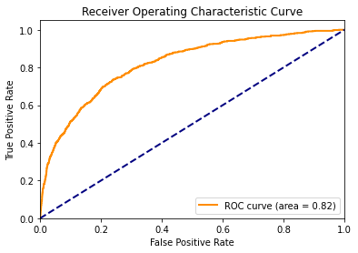

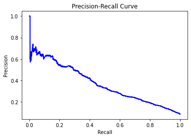

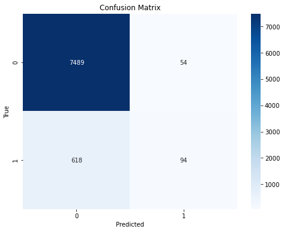

```python
# Initialize the Logistic Regression classifier
clf = LogisticRegression()

# Train the classifier on the training data and measure the time taken
start_time = time.time()
clf.fit(X_train, y_train)
end_time = time.time()

# Predict classes and probabilities for the validation set
pred = clf.predict(X_val)
pred_proba = clf.predict_proba(X_val)[:, 1]

# Calculate various performance metrics
accuracy = accuracy_score(y_val, pred)
precision = precision_score(y_val, pred)
recall = recall_score(y_val, pred)
f1 = f1_score(y_val, pred)
fpr, tpr, _ = roc_curve(y_val, pred_proba)
roc_auc = auc(fpr, tpr)
prec, rec, _ = precision_recall_curve(y_val, pred_proba)

# Display performance metrics
print('Accuracy:', accuracy)
print('Precision:', precision)
print('Recall:', recall)
print('F1 Score:', f1)
print("Runtime:", (end_time - start_time)/60, " minutes")

# Plot ROC curve
plt.figure()
plt.plot(fpr, tpr, color='darkorange', lw=2, label='ROC curve (area = %0.2f)' % roc_auc)
plt.plot([0, 1], [0, 1], color='navy', lw=2, linestyle='--')
plt.xlim([0.0, 1.0])
plt.ylim([0.0, 1.05])
plt.xlabel('False Positive Rate')
plt.ylabel('True Positive Rate')
plt.title('Receiver Operating Characteristic Curve')
plt.legend(loc="lower right")
plt.show()

# Plot Precision-Recall curve
plt.figure()
plt.plot(rec, prec, color='blue', lw=2)
plt.xlabel('Recall')
plt.ylabel('Precision')
plt.title('Precision-Recall Curve')
plt.show()

# Display confusion matrix using heatmap for better visualization
cm = confusion_matrix(y_val, pred)
plt.figure(figsize=(8, 6))
sns.heatmap(cm, annot=True, fmt='d', cmap='Blues')
plt.xlabel('Predicted')
plt.ylabel('True')
plt.title('Confusion Matrix')
plt.show()
```

Upon evaluating the models both with and without the presence of outliers, we have elected to retain the outliers in our dataset. This decision stems from our interest in identifying patients who exhibit atypical values, as these deviations may serve as potential indicators of medical anomalies. The consequent impact of this decision was evident in the results, particularly manifesting as a diminished recall rate.

1. Undersampling

In addressing the imbalance within the dataset, we employ undersampling rather than oversampling, given the abundance of examples present. To ascertain the most optimal approach, the geometric mean will be utilized as it offers enhanced robustness when confronted with class distribution disparities.

```python
# Define hyperparameters for Logistic Regression
hyperParams = { "logisticregression__C": [0.01, 0.1, 1, 10]}

# Define various undersampling techniques
rus = us.RandomUnderSampler(random_state=42, replacement=False)
tl = TomekLinks()
oss = OneSidedSelection(random_state=42)
cnn = CondensedNearestNeighbour(random_state=42)

# Define the scoring metric
geomean = make_scorer(geometric_mean_score)

# Lists to hold method names and their respective techniques
methodList = ['RUS', 'TL', 'OSS']
techniqueList = [rus, tl, oss]

# Initialize variables to store best results
bestResult = -1
bestMethod = None
bestConfig = None

# List to store validation results
GM_val_list = []

# Record start time for execution time calculation
start_time = time.time()

# Iterate over each undersampling technique
for name, technique in zip(methodList, techniqueList):
    # Create a pipeline with the current undersampling technique followed by Logistic Regression
    pipe = make_pipeline(technique, LogisticRegression(max_iter=300))

    # Perform grid search to find the best hyperparameters using cross-validation
    gsPipe = GridSearchCV(pipe, hyperParams, scoring=geomean, cv=5, n_jobs=-1)
    gsPipe.fit(X_train_comp, y_train_comp)

    # Append the best score to GM_val_list
    GM_val_list.append(gsPipe.best_score_)

    # Display the name of the technique and its performance
    print(f"{name}: {gsPipe.best_score_}")

    # Update best result variables if current result is better
    if gsPipe.best_score_ >= bestResult:
        bestResult = gsPipe.best_score_
        bestMethod = gsPipe.best_estimator_
        bestTec = technique
        name = name
        bestConfig = gsPipe.best_params_

# Record end time for execution time calculation
end_time = time.time()

# Display the results
print("\nBest sampling method:", bestMethod)
print("Best hyper-parameters:", bestConfig)
print("Best validation result:", bestResult)
print("Execution time:", (end_time - start_time)/60, " minutes")
```

```
RUS: 0.7626979077763667
TL: 0.45231560534690785
OSS: 0.45537651036813964

Best sampling method: Pipeline(steps=[('randomundersampler', RandomUnderSampler(random_state=42)),
                ('logisticregression', LogisticRegression(C=10, max_iter=300))])
Best hyper-parameters: {'logisticregression__C': 10}
Best validation result: 0.7626979077763667
Execution time: 0.9585044066111247  minutes
```

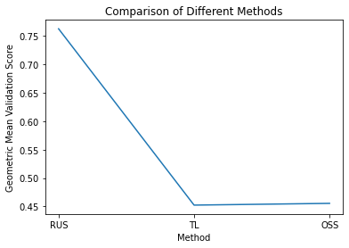

```python
# Plotting the geometric mean validation scores for each method

# Define the X and Y axis data
plt.plot(methodList, GM_val_list)

# Set the label for the X axis
plt.xlabel('Method')

# Set the label for the Y axis
plt.ylabel('Geometric Mean Validation Score')

# Set the title of the plot
plt.title('Comparison of Different Methods')

# Display the plot
plt.show()
```

```python
# Obtain the number of examples for each class in the original dataset
examplesPerClass = Counter(y_train_comp)
print(f'Original dataset, examples of class 0: {examplesPerClass[0]}, examples of class 1: {examplesPerClass[1]}')

# Resample the training data using the best sampling technique
X_train_sampled, y_train_sampled = bestTec.fit_resample(X_train_comp, y_train_comp)

# Obtain the number of examples for each class after sampling
sampledExamplesPerClass = Counter(y_train_sampled)
print(f'Dataset sampled with {name}, examples of class 0: {sampledExamplesPerClass[0]}, examples of class 1: {sampledExamplesPerClass[1]}')

# Determine the indices of examples that were removed during the sampling process
indicesOfRemovedExamples = np.setdiff1d(np.arange(X_train_uncorr.shape[0]), bestTec.sample_indices_)
print(f'The number of removed examples is {len(indicesOfRemovedExamples)}')
```

```
Original dataset, examples of class 0: 37709, examples of class 1: 3562
Dataset sampled with OSS, examples of class 0: 3562, examples of class 1: 3562
The number of removed examples is 34147
```

```python
# Display the shape of the sampled dataset
print(X_train_sampled.shape, y_train_sampled.shape)
```

```
(7124, 67) (7124,)
```

Basic Model evaluation

```
Accuracy: 0.7727437916414295
Precision: 0.2303058387395737
Recall: 0.6980337078651685
F1 Score: 0.3463414634146341
Execution time: 0.0007218480110168457 minutes
```

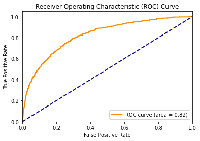

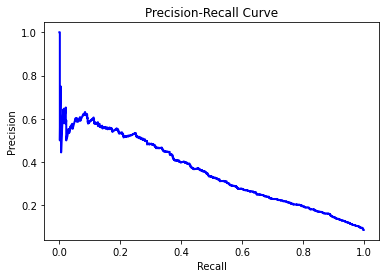

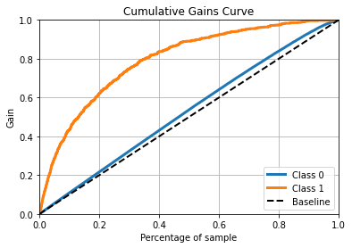

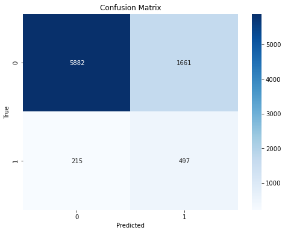

```python
# Initializing a logistic regression classifier
clf_with_noise = LogisticRegression()

# Tracking the start time for model training
start_time = time.time()

# Fitting the model on the sampled data
clf_with_noise.fit(X_train_sampled, y_train_sampled)

# Making predictions on the validation set
pred_with_noise = clf_with_noise.predict(X_val)
pred_proba_with_noise = clf_with_noise.predict_proba(X_val)[:, 1]

# Calculating the time taken to train and predict
end_time = time.time()

# Computing various evaluation metrics
accuracy_with_noise = accuracy_score(y_val, pred_with_noise)
precision_with_noise = precision_score(y_val, pred_with_noise)
recall_with_noise = recall_score(y_val, pred_with_noise)
f1_with_noise = f1_score(y_val, pred_with_noise)
fpr_with_noise, tpr_with_noise, _ = roc_curve(y_val, pred_proba_with_noise)
roc_auc_with_noise = auc(fpr_with_noise, tpr_with_noise)
prec_with_noise, rec_with_noise, _ = precision_recall_curve(y_val, pred_proba_with_noise)

# Displaying the results
print(f'Accuracy: {accuracy_with_noise}')
print(f'Precision: {precision_with_noise}')
print(f'Recall: {recall_with_noise}')
print(f'F1 Score: {f1_with_noise}')
print(f"Execution time: {(end_time - start_time)/60} minutes")

# Plotting the ROC curve
plt.figure()
plt.plot(fpr_with_noise, tpr_with_noise, color='darkorange', lw=2, label=f'ROC curve (area = {roc_auc_with_noise:.2f})')
plt.plot([0, 1], [0, 1], color='navy', lw=2, linestyle='--')
plt.xlim([0.0, 1.0])
plt.ylim([0.0, 1.05])
plt.xlabel('False Positive Rate')
plt.ylabel('True Positive Rate')
plt.title('Receiver Operating Characteristic (ROC) Curve')
plt.legend(loc="lower right")
plt.show()

# Plotting the Precision-Recall curve
plt.figure()
plt.plot(rec_with_noise, prec_with_noise, color='blue', lw=2)
plt.xlabel('Recall')
plt.ylabel('Precision')
plt.title('Precision-Recall Curve')
plt.show()

# Plotting the Cumulative Gain chart
skplt.metrics.plot_cumulative_gain(y_val, clf_with_noise.predict_proba(X_val))
plt.show()

# Plotting the confusion matrix
cm_with_noise = confusion_matrix(y_val, pred_with_noise)
plt.figure(figsize=(8, 6))
sns.heatmap(cm_with_noise, annot=True, fmt='d', cmap='Blues')
plt.xlabel('Predicted')
plt.ylabel('True')
plt.title('Confusion Matrix')
plt.show()
```

Removing noise

```python
# Define noise removal techniques
tl = TomekLinks(sampling_strategy='all')
all_knn = AllKNN(sampling_strategy='all', kind_sel='mode')
enn = EditedNearestNeighbours(sampling_strategy='all', kind_sel='mode')

techniqueList = [tl, enn, all_knn]
methodList = ["TL", "ENN", "ALLKNN"]

bestResultNoise = -1
bestMethodNoise = None
bestConfigNoise = None

# Store validation results for each technique
val_list = []

# Define stratified k-fold cross validation
skf = StratifiedKFold(n_splits=5)

# Define hyperparameters for Grid Search
hyperPar = { "logisticregression__C": [0.01, 0.1, 1, 10]}

# Record the starting time for execution
start_time = time.time()

# Iterate through each noise removal technique
for name, technique in zip(methodList, techniqueList):
    # Create a pipeline with noise removal and logistic regression
    pipe = make_pipeline(technique, LogisticRegression(max_iter=300))
    gsPipe = GridSearchCV(pipe, hyperPar, scoring='recall', cv=skf, n_jobs=-1)
    gsPipe.fit(X_train_sampled, y_train_sampled)
    val_list.append(gsPipe.best_score_)

    # Display the validation result for the current technique
    print(f"{name}: {gsPipe.best_score_}")

    # Check if current technique performs better than previous ones and update the best if necessary
    if gsPipe.best_score_ >= bestResultNoise:
        bestResultNoise = gsPipe.best_score_
        bestMethodNoise = gsPipe.best_estimator_
        bestNoiseTec = technique
        nameNoise = name
        bestConfig = gsPipe.best_params_

# Record the ending time for execution
end_time = time.time()

# Calculate and display the time taken for execution
execution_time = (end_time - start_time) / 60
print(f"Best result with {nameNoise} with a recall of {bestResultNoise:.2f}")
print(f"Execution time: {execution_time:.2f} minutes")
```

```
TL: 0.7405881147863907
ENN: 0.7012870920465828
ALLKNN: 0.7060592212049104
Best result with TL with a recall of 0.74
Execution time: 0.07 minutes
```

```python
# Count the number of examples for each class in the sampled dataset
examplesPerClass = Counter(y_train_sampled)

# Display the count of each class in the original sampled dataset
print(f'Original dataset, examples of class 0: {examplesPerClass[0]}, examples of class 1: {examplesPerClass[1]}')

# Resample the dataset to remove noise using the best noise removal technique
X_train_noNoise, y_train_noNoise = bestNoiseTec.fit_resample(X_train_sampled, y_train_sampled)

# Count the number of examples for each class in the no-noise dataset
noNoiseExamplesPerClass = Counter(y_train_noNoise)

# Display the count of each class in the no-noise dataset
print(f'No noise dataset with {nameNoise}, examples of class 0: {noNoiseExamplesPerClass[0]}, examples of class 1: {noNoiseExamplesPerClass[1]}')

# Calculate the indices of examples that were removed during the noise removal process
indicesExamplesEliminated = np.setdiff1d(np.arange(X_train_sampled.shape[0]), bestNoiseTec.sample_indices_)

# Display the number of examples that were removed
print(f'The number of examples eliminated is {len(indicesExamplesEliminated)}')
```

```
Original dataset, examples of class 0: 3562, examples of class 1: 3562
No noise dataset with TL, examples of class 0: 3079, examples of class 1: 3079
The number of examples eliminated is 966
```

Prediction Model Evaluation

1. Logistic Regression

```
Accuracy: 0.7681405208964264
Precision: 0.23000898472596587
Recall: 0.7191011235955056
F1 Score: 0.3485364193328795
Execution time: 0.00 minutes
```

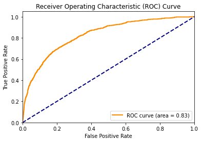

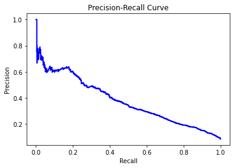

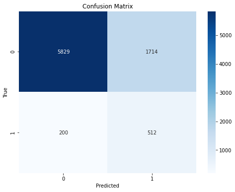

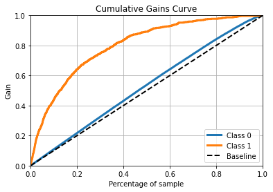

```python
# Initialize the Logistic Regression classifier
clf_without_noise = LogisticRegression()

# Record the start time for training the classifier
start_time = time.time()

# Train the classifier using the no-noise training dataset
clf_without_noise.fit(X_train_noNoise, y_train_noNoise)

# Predict the class labels and probabilities for the validation set
pred_without_noise = clf_without_noise.predict(X_val)
pred_proba_without_noise = clf_without_noise.predict_proba(X_val)[:, 1]

# Record the end time for training the classifier
end_time = time.time()

# Calculate evaluation metrics for the classifier's performance
accuracy_without_noise = accuracy_score(y_val, pred_without_noise)
precision_without_noise = precision_score(y_val, pred_without_noise)
recall_without_noise = recall_score(y_val, pred_without_noise)
f1_without_noise = f1_score(y_val, pred_without_noise)

# Display the evaluation metrics and execution time
print(f'Accuracy: {accuracy_without_noise}')
print(f'Precision: {precision_without_noise}')
print(f'Recall: {recall_without_noise}')
print(f'F1 Score: {f1_without_noise}')
print(f"Execution time: {(end_time - start_time) / 60:.2f} minutes")

# Plot the Receiver Operating Characteristic (ROC) curve
fpr_without_noise, tpr_without_noise, _ = roc_curve(y_val, pred_proba_without_noise)
roc_auc_without_noise = auc(fpr_without_noise, tpr_without_noise)
plt.figure()
plt.plot(fpr_without_noise, tpr_without_noise, color='darkorange', lw=2, label=f'ROC curve (area = {roc_auc_without_noise:.2f})')
plt.plot([0, 1], [0, 1], color='navy', lw=2, linestyle='--')
plt.xlim([0.0, 1.0])
plt.ylim([0.0, 1.05])
plt.xlabel('False Positive Rate')
plt.ylabel('True Positive Rate')
plt.title('Receiver Operating Characteristic (ROC) Curve')
plt.legend(loc="lower right")
plt.show()

# Plot the Precision-Recall curve
precision_curve_without_noise, recall_curve_without_noise, _ = precision_recall_curve(y_val, pred_proba_without_noise)
plt.figure()
plt.plot(recall_curve_without_noise, precision_curve_without_noise, color='blue', lw=2)
plt.xlabel('Recall')
plt.ylabel('Precision')
plt.title('Precision-Recall Curve')
plt.show()

# Plotting the confusion matrix
cm_without_noise = confusion_matrix(y_val, pred_without_noise)
plt.figure(figsize=(8, 6))
sns.heatmap(cm_without_noise, annot=True, fmt='d', cmap='Blues')
plt.xlabel('Predicted')
plt.ylabel('True')
plt.title('Confusion Matrix')
plt.show()

# Plot the Cumulative Gain using scikit-plot
skplt.metrics.plot_cumulative_gain(y_val, clf_without_noise.predict_proba(X_val))
plt.show()
```

1. Random Forest

```
nan% +/- nan% {'criterion': 'gini', 'max_features': 'auto', 'min_samples_leaf': 0.01, 'min_samples_split': 0.02, 'n_estimators': 100}
nan% +/- nan% {'criterion': 'gini', 'max_features': 'auto', 'min_samples_leaf': 0.01, 'min_samples_split': 0.02, 'n_estimators': 200}
nan% +/- nan% {'criterion': 'gini', 'max_features': 'auto', 'min_samples_leaf': 0.01, 'min_samples_split': 0.02, 'n_estimators': 500}
nan% +/- nan% {'criterion': 'gini', 'max_features': 'auto', 'min_samples_leaf': 0.01, 'min_samples_split': 0.04, 'n_estimators': 100}
nan% +/- nan% {'criterion': 'gini', 'max_features': 'auto', 'min_samples_leaf': 0.01, 'min_samples_split': 0.04, 'n_estimators': 200}
nan% +/- nan% {'criterion': 'gini', 'max_features': 'auto', 'min_samples_leaf': 0.01, 'min_samples_split': 0.04, 'n_estimators': 500}
nan% +/- nan% {'criterion': 'gini', 'max_features': 'auto', 'min_samples_leaf': 0.01, 'min_samples_split': 0.06, 'n_estimators': 100}
nan% +/- nan% {'criterion': 'gini', 'max_features': 'auto', 'min_samples_leaf': 0.01, 'min_samples_split': 0.06, 'n_estimators': 200}
nan% +/- nan% {'criterion': 'gini', 'max_features': 'auto', 'min_samples_leaf': 0.01, 'min_samples_split': 0.06, 'n_estimators': 500}
nan% +/- nan% {'criterion': 'gini', 'max_features': 'auto', 'min_samples_leaf': 0.01, 'min_samples_split': 0.08, 'n_estimators': 100}
nan% +/- nan% {'criterion': 'gini', 'max_features': 'auto', 'min_samples_leaf': 0.01, 'min_samples_split': 0.08, 'n_estimators': 200}
nan% +/- nan% {'criterion': 'gini', 'max_features': 'auto', 'min_samples_leaf': 0.01, 'min_samples_split': 0.08, 'n_estimators': 500}
nan% +/- nan% {'criterion': 'gini', 'max_features': 'auto', 'min_samples_leaf': 0.01, 'min_samples_split': 0.1, 'n_estimators': 100}
nan% +/- nan% {'criterion': 'gini', 'max_features': 'auto', 'min_samples_leaf': 0.01, 'min_samples_split': 0.1, 'n_estimators': 200}
nan% +/- nan% {'criterion': 'gini', 'max_features': 'auto', 'min_samples_leaf': 0.01, 'min_samples_split': 0.1, 'n_estimators': 500}
nan% +/- nan% {'criterion': 'gini', 'max_features': 'auto', 'min_samples_leaf': 0.02, 'min_samples_split': 0.02, 'n_estimators': 100}
nan% +/- nan% {'criterion': 'gini', 'max_features': 'auto', 'min_samples_leaf': 0.02, 'min_samples_split': 0.02, 'n_estimators': 200}
nan% +/- nan% {'criterion': 'gini', 'max_features': 'auto', 'min_samples_leaf': 0.02, 'min_samples_split': 0.02, 'n_estimators': 500}
nan% +/- nan% {'criterion': 'gini', 'max_features': 'auto', 'min_samples_leaf': 0.02, 'min_samples_split': 0.04, 'n_estimators': 100}
nan% +/- nan% {'criterion': 'gini', 'max_features': 'auto', 'min_samples_leaf': 0.02, 'min_samples_split': 0.04, 'n_estimators': 200}
nan% +/- nan% {'criterion': 'gini', 'max_features': 'auto', 'min_samples_leaf': 0.02, 'min_samples_split': 0.04, 'n_estimators': 500}
nan% +/- nan% {'criterion': 'gini', 'max_features': 'auto', 'min_samples_leaf': 0.02, 'min_samples_split': 0.06, 'n_estimators': 100}
nan% +/- nan% {'criterion': 'gini', 'max_features': 'auto', 'min_samples_leaf': 0.02, 'min_samples_split': 0.06, 'n_estimators': 200}
nan% +/- nan% {'criterion': 'gini', 'max_features': 'auto', 'min_samples_leaf': 0.02, 'min_samples_split': 0.06, 'n_estimators': 500}
nan% +/- nan% {'criterion': 'gini', 'max_features': 'auto', 'min_samples_leaf': 0.02, 'min_samples_split': 0.08, 'n_estimators': 100}
nan% +/- nan% {'criterion': 'gini', 'max_features': 'auto', 'min_samples_leaf': 0.02, 'min_samples_split': 0.08, 'n_estimators': 200}
nan% +/- nan% {'criterion': 'gini', 'max_features': 'auto', 'min_samples_leaf': 0.02, 'min_samples_split': 0.08, 'n_estimators': 500}
nan% +/- nan% {'criterion': 'gini', 'max_features': 'auto', 'min_samples_leaf': 0.02, 'min_samples_split': 0.1, 'n_estimators': 100}
nan% +/- nan% {'criterion': 'gini', 'max_features': 'auto', 'min_samples_leaf': 0.02, 'min_samples_split': 0.1, 'n_estimators': 200}
nan% +/- nan% {'criterion': 'gini', 'max_features': 'auto', 'min_samples_leaf': 0.02, 'min_samples_split': 0.1, 'n_estimators': 500}
nan% +/- nan% {'criterion': 'gini', 'max_features': 'auto', 'min_samples_leaf': 0.03, 'min_samples_split': 0.02, 'n_estimators': 100}
nan% +/- nan% {'criterion': 'gini', 'max_features': 'auto', 'min_samples_leaf': 0.03, 'min_samples_split': 0.02, 'n_estimators': 200}
nan% +/- nan% {'criterion': 'gini', 'max_features': 'auto', 'min_samples_leaf': 0.03, 'min_samples_split': 0.02, 'n_estimators': 500}
nan% +/- nan% {'criterion': 'gini', 'max_features': 'auto', 'min_samples_leaf': 0.03, 'min_samples_split': 0.04, 'n_estimators': 100}
nan% +/- nan% {'criterion': 'gini', 'max_features': 'auto', 'min_samples_leaf': 0.03, 'min_samples_split': 0.04, 'n_estimators': 200}
nan% +/- nan% {'criterion': 'gini', 'max_features': 'auto', 'min_samples_leaf': 0.03, 'min_samples_split': 0.04, 'n_estimators': 500}
nan% +/- nan% {'criterion': 'gini', 'max_features': 'auto', 'min_samples_leaf': 0.03, 'min_samples_split': 0.06, 'n_estimators': 100}
nan% +/- nan% {'criterion': 'gini', 'max_features': 'auto', 'min_samples_leaf': 0.03, 'min_samples_split': 0.06, 'n_estimators': 200}
nan% +/- nan% {'criterion': 'gini', 'max_features': 'auto', 'min_samples_leaf': 0.03, 'min_samples_split': 0.06, 'n_estimators': 500}
nan% +/- nan% {'criterion': 'gini', 'max_features': 'auto', 'min_samples_leaf': 0.03, 'min_samples_split': 0.08, 'n_estimators': 100}
```

[output cut: 491 more lines]

```
80.94% +/- 1.67% {'criterion': 'entropy', 'max_features': 'log2', 'min_samples_leaf': 0.1, 'min_samples_split': 0.06, 'n_estimators': 100}
79.54% +/- 2.31% {'criterion': 'entropy', 'max_features': 'log2', 'min_samples_leaf': 0.1, 'min_samples_split': 0.06, 'n_estimators': 200}
79.05% +/- 2.11% {'criterion': 'entropy', 'max_features': 'log2', 'min_samples_leaf': 0.1, 'min_samples_split': 0.06, 'n_estimators': 500}
80.94% +/- 1.67% {'criterion': 'entropy', 'max_features': 'log2', 'min_samples_leaf': 0.1, 'min_samples_split': 0.08, 'n_estimators': 100}
79.54% +/- 2.31% {'criterion': 'entropy', 'max_features': 'log2', 'min_samples_leaf': 0.1, 'min_samples_split': 0.08, 'n_estimators': 200}
79.05% +/- 2.11% {'criterion': 'entropy', 'max_features': 'log2', 'min_samples_leaf': 0.1, 'min_samples_split': 0.08, 'n_estimators': 500}
80.94% +/- 1.67% {'criterion': 'entropy', 'max_features': 'log2', 'min_samples_leaf': 0.1, 'min_samples_split': 0.1, 'n_estimators': 100}
79.54% +/- 2.31% {'criterion': 'entropy', 'max_features': 'log2', 'min_samples_leaf': 0.1, 'min_samples_split': 0.1, 'n_estimators': 200}
79.05% +/- 2.11% {'criterion': 'entropy', 'max_features': 'log2', 'min_samples_leaf': 0.1, 'min_samples_split': 0.1, 'n_estimators': 500}
Best params:  {'criterion': 'gini', 'max_features': 'log2', 'min_samples_leaf': 0.01, 'min_samples_split': 0.08, 'n_estimators': 200}
Accuracy: 0.7913062440939158
Precision: 0.2640134529147982
Recall: 0.793597304128054
F1 Score: 0.3962145110410095
Execution time: 3.58 minutes
```

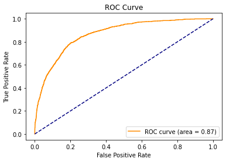

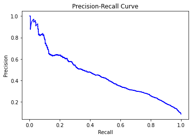

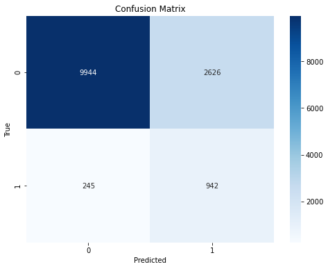

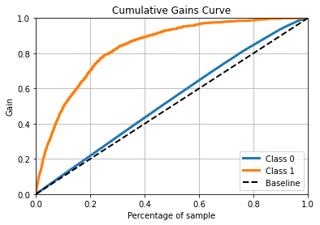

```python
# Defining a grid of hyperparameters for the RandomForestClassifier
param_grid = {
    "criterion": ["gini", "entropy"],
    "min_samples_split": [0.02, 0.04, 0.06, 0.08, 0.1],
    "min_samples_leaf": [0.01, 0.02, 0.03, 0.05, 0.07, 0.1],
    "n_estimators": [100, 200, 500],
    "max_features": ['auto', 'sqrt', 'log2']
}

# Initialize GridSearchCV with the RandomForestClassifier and the specified hyperparameters
gridSearch_pipe = model_selection.GridSearchCV(
    RandomForestClassifier(random_state=123), param_grid, scoring='recall', cv=5, n_jobs=-1
)

# Capture the starting time before fitting the grid search
start_time = time.time()

# Fitting the GridSearchCV on the no-noise training data
gridSearch_pipe.fit(X_train_noNoise, y_train_noNoise)

# Iterating through the results to display the mean and standard deviation of the test scores
results_dict = gridSearch_pipe.cv_results_
for i in range(len(results_dict["params"])):
    print(
        "{:.2f}% +/- {:.2f}%".format(
            results_dict["mean_test_score"][i] * 100.0,
            results_dict["std_test_score"][i] * 100.0,
        ),
        end=" ",
    )
    print(results_dict["params"][i])

# Fetch the best estimator and its parameters from the grid search
best_pipe_rf = gridSearch_pipe.best_estimator_
best_params_rf = gridSearch_pipe.best_params_

# Predict class labels and probabilities using the best model
pred_rf = best_pipe_rf.predict(X_test_uncorr)
pred_proba_rf = best_pipe_rf.predict_proba(X_test_uncorr)[:, 1]

# Calculate various metrics for the model's performance
accuracy_rf = accuracy_score(y_test, pred_rf)
precision_rf = precision_score(y_test, pred_rf)
recall_rf = recall_score(y_test, pred_rf)
f1_rf = f1_score(y_test, pred_rf)

# Display the performance metrics and execution time
print("Best params: ", best_params_rf)
print('Accuracy:', accuracy_rf)
print('Precision:', precision_rf)
print('Recall:', recall_rf)
print('F1 Score:', f1_rf)
end_time = time.time()
print(f"Execution time: {(end_time - start_time) / 60:.2f} minutes")

# Plot the Receiver Operating Characteristic (ROC) curve
fpr_rf, tpr_rf, _ = roc_curve(y_test, pred_proba_rf)
roc_auc_rf = auc(fpr_rf, tpr_rf)
plt.figure()
plt.plot(fpr_rf, tpr_rf, color='darkorange', label=f'ROC curve (area = {roc_auc_rf:.2f})')
plt.plot([0, 1], [0, 1], color='navy', linestyle='--')
plt.xlabel('False Positive Rate')
plt.ylabel('True Positive Rate')
plt.title('ROC Curve')
plt.legend(loc="lower right")
plt.show()

# Plot the Precision-Recall curve
precision_curve_rf, recall_curve_rf, _ = precision_recall_curve(y_test, pred_proba_rf)
plt.figure()
plt.plot(recall_curve_rf, precision_curve_rf, color='blue')
plt.xlabel('Recall')
plt.ylabel('Precision')
plt.title('Precision-Recall Curve')
plt.show()

# Plotting the confusion matrix
cm_rf = confusion_matrix(y_test, pred_rf)
plt.figure(figsize=(8, 6))
sns.heatmap(cm_rf, annot=True, fmt='d', cmap='Blues')
plt.xlabel('Predicted')
plt.ylabel('True')
plt.title('Confusion Matrix')
plt.show()

# Plot the Cumulative Gain using scikit-plot
skplt.metrics.plot_cumulative_gain(y_test, best_pipe_rf.predict_proba(X_test_uncorr))
plt.show()
```

1. GBM

```
81.88% +/- 1.79% {'learning_rate': 0.1, 'max_depth': 3, 'n_estimators': 100, 'subsample': 0.5}
81.65% +/- 2.29% {'learning_rate': 0.1, 'max_depth': 3, 'n_estimators': 100, 'subsample': 0.8}
81.75% +/- 2.13% {'learning_rate': 0.1, 'max_depth': 3, 'n_estimators': 100, 'subsample': 1.0}
82.50% +/- 1.96% {'learning_rate': 0.1, 'max_depth': 3, 'n_estimators': 200, 'subsample': 0.5}
81.85% +/- 2.33% {'learning_rate': 0.1, 'max_depth': 3, 'n_estimators': 200, 'subsample': 0.8}
81.65% +/- 2.00% {'learning_rate': 0.1, 'max_depth': 3, 'n_estimators': 200, 'subsample': 1.0}
82.30% +/- 1.65% {'learning_rate': 0.1, 'max_depth': 3, 'n_estimators': 300, 'subsample': 0.5}
81.78% +/- 2.00% {'learning_rate': 0.1, 'max_depth': 3, 'n_estimators': 300, 'subsample': 0.8}
81.88% +/- 2.04% {'learning_rate': 0.1, 'max_depth': 3, 'n_estimators': 300, 'subsample': 1.0}
81.62% +/- 1.62% {'learning_rate': 0.1, 'max_depth': 5, 'n_estimators': 100, 'subsample': 0.5}
81.68% +/- 2.23% {'learning_rate': 0.1, 'max_depth': 5, 'n_estimators': 100, 'subsample': 0.8}
82.46% +/- 1.90% {'learning_rate': 0.1, 'max_depth': 5, 'n_estimators': 100, 'subsample': 1.0}
81.65% +/- 1.65% {'learning_rate': 0.1, 'max_depth': 5, 'n_estimators': 200, 'subsample': 0.5}
81.78% +/- 1.94% {'learning_rate': 0.1, 'max_depth': 5, 'n_estimators': 200, 'subsample': 0.8}
82.75% +/- 2.16% {'learning_rate': 0.1, 'max_depth': 5, 'n_estimators': 200, 'subsample': 1.0}
81.91% +/- 1.93% {'learning_rate': 0.1, 'max_depth': 5, 'n_estimators': 300, 'subsample': 0.5}
81.75% +/- 1.65% {'learning_rate': 0.1, 'max_depth': 5, 'n_estimators': 300, 'subsample': 0.8}
82.69% +/- 2.14% {'learning_rate': 0.1, 'max_depth': 5, 'n_estimators': 300, 'subsample': 1.0}
82.20% +/- 1.41% {'learning_rate': 0.1, 'max_depth': 7, 'n_estimators': 100, 'subsample': 0.5}
82.17% +/- 2.86% {'learning_rate': 0.1, 'max_depth': 7, 'n_estimators': 100, 'subsample': 0.8}
82.56% +/- 1.70% {'learning_rate': 0.1, 'max_depth': 7, 'n_estimators': 100, 'subsample': 1.0}
82.66% +/- 2.18% {'learning_rate': 0.1, 'max_depth': 7, 'n_estimators': 200, 'subsample': 0.5}
82.98% +/- 2.39% {'learning_rate': 0.1, 'max_depth': 7, 'n_estimators': 200, 'subsample': 0.8}
82.66% +/- 1.95% {'learning_rate': 0.1, 'max_depth': 7, 'n_estimators': 200, 'subsample': 1.0}
82.46% +/- 1.74% {'learning_rate': 0.1, 'max_depth': 7, 'n_estimators': 300, 'subsample': 0.5}
82.95% +/- 2.52% {'learning_rate': 0.1, 'max_depth': 7, 'n_estimators': 300, 'subsample': 0.8}
82.92% +/- 2.08% {'learning_rate': 0.1, 'max_depth': 7, 'n_estimators': 300, 'subsample': 1.0}
78.50% +/- 2.07% {'learning_rate': 0.01, 'max_depth': 3, 'n_estimators': 100, 'subsample': 0.5}
78.60% +/- 1.77% {'learning_rate': 0.01, 'max_depth': 3, 'n_estimators': 100, 'subsample': 0.8}
78.01% +/- 1.97% {'learning_rate': 0.01, 'max_depth': 3, 'n_estimators': 100, 'subsample': 1.0}
79.64% +/- 2.10% {'learning_rate': 0.01, 'max_depth': 3, 'n_estimators': 200, 'subsample': 0.5}
79.38% +/- 2.00% {'learning_rate': 0.01, 'max_depth': 3, 'n_estimators': 200, 'subsample': 0.8}
79.15% +/- 1.92% {'learning_rate': 0.01, 'max_depth': 3, 'n_estimators': 200, 'subsample': 1.0}
80.45% +/- 1.76% {'learning_rate': 0.01, 'max_depth': 3, 'n_estimators': 300, 'subsample': 0.5}
80.68% +/- 1.86% {'learning_rate': 0.01, 'max_depth': 3, 'n_estimators': 300, 'subsample': 0.8}
80.19% +/- 1.93% {'learning_rate': 0.01, 'max_depth': 3, 'n_estimators': 300, 'subsample': 1.0}
80.25% +/- 2.30% {'learning_rate': 0.01, 'max_depth': 5, 'n_estimators': 100, 'subsample': 0.5}
80.03% +/- 2.13% {'learning_rate': 0.01, 'max_depth': 5, 'n_estimators': 100, 'subsample': 0.8}
79.44% +/- 2.23% {'learning_rate': 0.01, 'max_depth': 5, 'n_estimators': 100, 'subsample': 1.0}
81.10% +/- 1.96% {'learning_rate': 0.01, 'max_depth': 5, 'n_estimators': 200, 'subsample': 0.5}
```

[output cut: 32 more lines]

```
80.55% +/- 2.23% {'learning_rate': 0.001, 'max_depth': 7, 'n_estimators': 100, 'subsample': 0.5}
81.03% +/- 2.19% {'learning_rate': 0.001, 'max_depth': 7, 'n_estimators': 100, 'subsample': 0.8}
77.49% +/- 2.35% {'learning_rate': 0.001, 'max_depth': 7, 'n_estimators': 100, 'subsample': 1.0}
80.45% +/- 2.04% {'learning_rate': 0.001, 'max_depth': 7, 'n_estimators': 200, 'subsample': 0.5}
80.64% +/- 2.43% {'learning_rate': 0.001, 'max_depth': 7, 'n_estimators': 200, 'subsample': 0.8}
78.08% +/- 2.83% {'learning_rate': 0.001, 'max_depth': 7, 'n_estimators': 200, 'subsample': 1.0}
80.71% +/- 1.80% {'learning_rate': 0.001, 'max_depth': 7, 'n_estimators': 300, 'subsample': 0.5}
80.81% +/- 2.28% {'learning_rate': 0.001, 'max_depth': 7, 'n_estimators': 300, 'subsample': 0.8}
78.70% +/- 2.39% {'learning_rate': 0.001, 'max_depth': 7, 'n_estimators': 300, 'subsample': 1.0}
Best params:  {'learning_rate': 0.1, 'max_depth': 7, 'n_estimators': 200, 'subsample': 0.8}
Accuracy: 0.7954495892999928
Precision: 0.2724475524475524
Recall: 0.8205560235888796
F1 Score: 0.4090718185636287
Execution time: 8.24 minutes
```

[figure not shown]

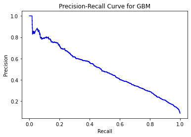

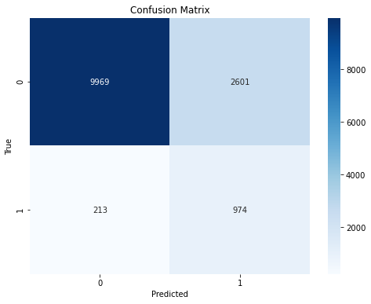

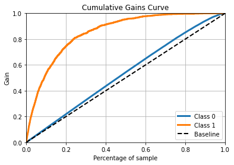

```python
# Defining a hyperparameter grid for Gradient Boosting Classifier
param_grid = {
    "learning_rate": [0.1, 0.01, 0.001],
    "n_estimators": [100, 200, 300],
    "subsample": [0.5, 0.8, 1.0],
    "max_depth": [3, 5, 7],
}

# Initializing GridSearchCV with GradientBoostingClassifier and the specified hyperparameters
gridSearch_pipe = model_selection.GridSearchCV(
    GradientBoostingClassifier(random_state=123), param_grid, scoring='recall', cv=5, n_jobs=-1
)

# Capture the starting time before fitting the grid search
start_time = time.time()

# Fit the GridSearchCV on the no-noise training data
gridSearch_pipe.fit(X_train_noNoise, y_train_noNoise)

# Display the results in a readable format
results_dict = gridSearch_pipe.cv_results_
for i in range(len(results_dict["params"])):
    print(
        "{:.2f}% +/- {:.2f}%".format(
            results_dict["mean_test_score"][i] * 100.0,
            results_dict["std_test_score"][i] * 100.0,
        ),
        end=" ",
    )
    print(results_dict["params"][i])

# Fetch the best estimator and its parameters from the grid search
best_pipe_gbm = gridSearch_pipe.best_estimator_
best_params_gbm = gridSearch_pipe.best_params_

# Predict class labels and probabilities using the best model
pred_gbm = best_pipe_gbm.predict(X_test_uncorr)
pred_proba_gbm = best_pipe_gbm.predict_proba(X_test_uncorr)[:, 1]

# Calculate various performance metrics for the model
accuracy_gbm = accuracy_score(y_test, pred_gbm)
precision_gbm = precision_score(y_test, pred_gbm)
recall_gbm = recall_score(y_test, pred_gbm)
f1_gbm = f1_score(y_test, pred_gbm)

# Display performance metrics and execution time
print("Best params: ", best_params_gbm)
print('Accuracy:', accuracy_gbm)
print('Precision:', precision_gbm)
print('Recall:', recall_gbm)
print('F1 Score:', f1_gbm)
end_time = time.time()
print(f"Execution time: {(end_time - start_time) / 60:.2f} minutes")

# Plot the Receiver Operating Characteristic (ROC) curve
fpr_gbm, tpr_gbm, _ = roc_curve(y_test, pred_proba_gbm)
roc_auc_gbm = auc(fpr_gbm, tpr_gbm)
plt.figure()
plt.plot(fpr, tpr, color='darkorange', label=f'ROC curve (area = {roc_auc_gbm:.2f})')
plt.plot([0, 1], [0, 1], color='navy', linestyle='--')
plt.xlabel('False Positive Rate')
plt.ylabel('True Positive Rate')
plt.title('ROC Curve for GBM')
plt.legend(loc="lower right")
plt.show()

# Plot the Precision-Recall curve
precision_curve_gbm, recall_curve_gbm, _ = precision_recall_curve(y_test, pred_proba_gbm)
plt.figure()
plt.plot(recall_curve_gbm, precision_curve_gbm, color='blue')
plt.xlabel('Recall')
plt.ylabel('Precision')
plt.title('Precision-Recall Curve for GBM')
plt.show()

# Plotting the confusion matrix
cm_gbm = confusion_matrix(y_test, pred_gbm)
plt.figure(figsize=(8, 6))
sns.heatmap(cm_gbm, annot=True, fmt='d', cmap='Blues')
plt.xlabel('Predicted')
plt.ylabel('True')
plt.title('Confusion Matrix')
plt.show()

# Plot the Cumulative Gain for GBM using scikit-plot
skplt.metrics.plot_cumulative_gain(y_test, best_pipe_gbm.predict_proba(X_test_uncorr))
plt.show()
```

1. XGB model

```python
original_columns = X_train_noNoise.columns.tolist()

new_columns = range(len(original_columns))

X_train_noNoise.columns = new_columns

print(X_train_noNoise.info())
```

```
<class 'pandas.core.frame.DataFrame'>
RangeIndex: 6158 entries, 0 to 6157
Data columns (total 67 columns):
 #   Column  Non-Null Count  Dtype
---  ------  --------------  -----
 0   0       6158 non-null   float64
 1   1       6158 non-null   float64
 2   2       6158 non-null   float64
 3   3       6158 non-null   float64
 4   4       6158 non-null   float64
 5   5       6158 non-null   float64
 6   6       6158 non-null   float64
 7   7       6158 non-null   float64
 8   8       6158 non-null   float64
 9   9       6158 non-null   float64
```

[output cut: 60 more lines]

```python
original_columns = X_test_uncorr.columns.tolist()

new_columns = range(len(original_columns))

X_test_uncorr.columns = new_columns

print(X_test_uncorr.info())
```

```
<class 'pandas.core.frame.DataFrame'>
RangeIndex: 13757 entries, 0 to 13756
Data columns (total 67 columns):
 #   Column  Non-Null Count  Dtype
---  ------  --------------  -----
 0   0       13757 non-null  float64
 1   1       13757 non-null  float64
 2   2       13757 non-null  float64
 3   3       13757 non-null  float64
 4   4       13757 non-null  float64
 5   5       13757 non-null  float64
 6   6       13757 non-null  float64
 7   7       13757 non-null  float64
 8   8       13757 non-null  float64
 9   9       13757 non-null  float64
```

[output cut: 60 more lines]

```
81.91% +/- 1.14% {'learning_rate': 0.1, 'max_depth': 3, 'n_estimators': 100, 'subsample': 0.5}
81.23% +/- 1.58% {'learning_rate': 0.1, 'max_depth': 3, 'n_estimators': 100, 'subsample': 0.8}
81.52% +/- 1.45% {'learning_rate': 0.1, 'max_depth': 3, 'n_estimators': 100, 'subsample': 1.0}
82.36% +/- 1.64% {'learning_rate': 0.1, 'max_depth': 3, 'n_estimators': 200, 'subsample': 0.5}
81.81% +/- 1.97% {'learning_rate': 0.1, 'max_depth': 3, 'n_estimators': 200, 'subsample': 0.8}
81.72% +/- 2.09% {'learning_rate': 0.1, 'max_depth': 3, 'n_estimators': 200, 'subsample': 1.0}
82.20% +/- 2.17% {'learning_rate': 0.1, 'max_depth': 3, 'n_estimators': 300, 'subsample': 0.5}
82.14% +/- 1.78% {'learning_rate': 0.1, 'max_depth': 3, 'n_estimators': 300, 'subsample': 0.8}
81.98% +/- 1.49% {'learning_rate': 0.1, 'max_depth': 3, 'n_estimators': 300, 'subsample': 1.0}
82.56% +/- 1.81% {'learning_rate': 0.1, 'max_depth': 5, 'n_estimators': 100, 'subsample': 0.5}
82.85% +/- 1.73% {'learning_rate': 0.1, 'max_depth': 5, 'n_estimators': 100, 'subsample': 0.8}
82.20% +/- 2.16% {'learning_rate': 0.1, 'max_depth': 5, 'n_estimators': 100, 'subsample': 1.0}
82.79% +/- 1.72% {'learning_rate': 0.1, 'max_depth': 5, 'n_estimators': 200, 'subsample': 0.5}
82.82% +/- 1.92% {'learning_rate': 0.1, 'max_depth': 5, 'n_estimators': 200, 'subsample': 0.8}
82.20% +/- 2.52% {'learning_rate': 0.1, 'max_depth': 5, 'n_estimators': 200, 'subsample': 1.0}
82.23% +/- 1.65% {'learning_rate': 0.1, 'max_depth': 5, 'n_estimators': 300, 'subsample': 0.5}
82.53% +/- 1.48% {'learning_rate': 0.1, 'max_depth': 5, 'n_estimators': 300, 'subsample': 0.8}
82.79% +/- 2.53% {'learning_rate': 0.1, 'max_depth': 5, 'n_estimators': 300, 'subsample': 1.0}
82.30% +/- 1.57% {'learning_rate': 0.1, 'max_depth': 7, 'n_estimators': 100, 'subsample': 0.5}
81.88% +/- 1.38% {'learning_rate': 0.1, 'max_depth': 7, 'n_estimators': 100, 'subsample': 0.8}
82.43% +/- 1.93% {'learning_rate': 0.1, 'max_depth': 7, 'n_estimators': 100, 'subsample': 1.0}
82.33% +/- 1.77% {'learning_rate': 0.1, 'max_depth': 7, 'n_estimators': 200, 'subsample': 0.5}
82.62% +/- 1.69% {'learning_rate': 0.1, 'max_depth': 7, 'n_estimators': 200, 'subsample': 0.8}
82.59% +/- 1.71% {'learning_rate': 0.1, 'max_depth': 7, 'n_estimators': 200, 'subsample': 1.0}
82.17% +/- 1.79% {'learning_rate': 0.1, 'max_depth': 7, 'n_estimators': 300, 'subsample': 0.5}
82.17% +/- 1.41% {'learning_rate': 0.1, 'max_depth': 7, 'n_estimators': 300, 'subsample': 0.8}
82.33% +/- 2.09% {'learning_rate': 0.1, 'max_depth': 7, 'n_estimators': 300, 'subsample': 1.0}
78.11% +/- 2.02% {'learning_rate': 0.01, 'max_depth': 3, 'n_estimators': 100, 'subsample': 0.5}
77.92% +/- 2.13% {'learning_rate': 0.01, 'max_depth': 3, 'n_estimators': 100, 'subsample': 0.8}
77.59% +/- 2.39% {'learning_rate': 0.01, 'max_depth': 3, 'n_estimators': 100, 'subsample': 1.0}
79.41% +/- 1.85% {'learning_rate': 0.01, 'max_depth': 3, 'n_estimators': 200, 'subsample': 0.5}
79.47% +/- 2.02% {'learning_rate': 0.01, 'max_depth': 3, 'n_estimators': 200, 'subsample': 0.8}
78.99% +/- 2.24% {'learning_rate': 0.01, 'max_depth': 3, 'n_estimators': 200, 'subsample': 1.0}
80.09% +/- 1.39% {'learning_rate': 0.01, 'max_depth': 3, 'n_estimators': 300, 'subsample': 0.5}
80.68% +/- 1.77% {'learning_rate': 0.01, 'max_depth': 3, 'n_estimators': 300, 'subsample': 0.8}
80.25% +/- 2.01% {'learning_rate': 0.01, 'max_depth': 3, 'n_estimators': 300, 'subsample': 1.0}
79.90% +/- 1.81% {'learning_rate': 0.01, 'max_depth': 5, 'n_estimators': 100, 'subsample': 0.5}
79.73% +/- 1.91% {'learning_rate': 0.01, 'max_depth': 5, 'n_estimators': 100, 'subsample': 0.8}
79.47% +/- 2.12% {'learning_rate': 0.01, 'max_depth': 5, 'n_estimators': 100, 'subsample': 1.0}
80.77% +/- 2.05% {'learning_rate': 0.01, 'max_depth': 5, 'n_estimators': 200, 'subsample': 0.5}
```

[output cut: 32 more lines]

```
80.74% +/- 2.08% {'learning_rate': 0.001, 'max_depth': 7, 'n_estimators': 100, 'subsample': 0.5}
80.68% +/- 1.98% {'learning_rate': 0.001, 'max_depth': 7, 'n_estimators': 100, 'subsample': 0.8}
78.11% +/- 2.32% {'learning_rate': 0.001, 'max_depth': 7, 'n_estimators': 100, 'subsample': 1.0}
80.74% +/- 1.94% {'learning_rate': 0.001, 'max_depth': 7, 'n_estimators': 200, 'subsample': 0.5}
80.68% +/- 2.00% {'learning_rate': 0.001, 'max_depth': 7, 'n_estimators': 200, 'subsample': 0.8}
78.08% +/- 2.39% {'learning_rate': 0.001, 'max_depth': 7, 'n_estimators': 200, 'subsample': 1.0}
80.81% +/- 1.75% {'learning_rate': 0.001, 'max_depth': 7, 'n_estimators': 300, 'subsample': 0.5}
80.68% +/- 2.03% {'learning_rate': 0.001, 'max_depth': 7, 'n_estimators': 300, 'subsample': 0.8}
79.28% +/- 2.92% {'learning_rate': 0.001, 'max_depth': 7, 'n_estimators': 300, 'subsample': 1.0}
Best params:  {'learning_rate': 0.1, 'max_depth': 5, 'n_estimators': 100, 'subsample': 0.8}
Accuracy: 0.8015555717089482
Precision: 0.27811331607707795
Recall: 0.814658803706824
F1 Score: 0.4146655231560892
Execution time: 2.0942981561024983  minutes
```

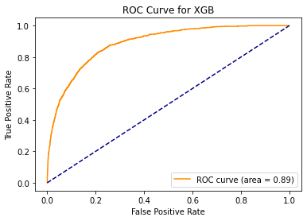

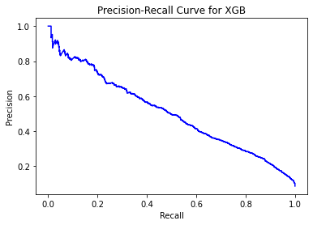

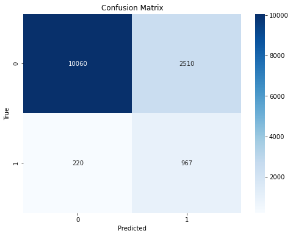

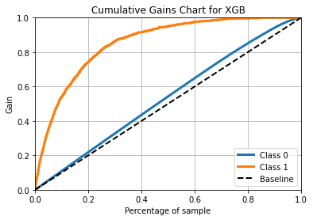

```python
# Create the hyperparameter grid
param_grid = {
    "learning_rate": [0.1, 0.01, 0.001],
    "n_estimators": [100, 200, 300],
    "subsample": [0.5, 0.8, 1.0],
    "max_depth": [3, 5, 7],
}

# Initialize GridSearchCV with XGBoost classifier
gridSearch_pipe = model_selection.GridSearchCV(
    XGBClassifier(use_label_encoder=False, eval_metric='logloss', random_state=123),
    param_grid,
    scoring='recall',
    cv=5,
    n_jobs=-1
)

# Record starting time for performance measurement
start_time = time.time()

# Standardize column names to prevent errors
X_train_noNoise.columns = [str(i) for i in range(X_train_noNoise.shape[1])]
X_test_uncorr.columns = [str(i) for i in range(X_test_uncorr.shape[1])]

# Fit the GridSearchCV to the training data
gridSearch_pipe.fit(X_train_noNoise, y_train_noNoise)

# Store the DataFrame with the results
diccionarioResultados = gridSearch_pipe.cv_results_

# Display GridSearch results
for i in range(len(diccionarioResultados["params"])):
    print("{:.2f}% +/- {:.2f}%".format(diccionarioResultados["mean_test_score"][i] * 100.0, diccionarioResultados["std_test_score"][i] * 100.0), end=" ")
    print(diccionarioResultados["params"][i])

# Extract best estimator and its parameters
best_pipe_xgb = gridSearch_pipe.best_estimator_
best_params_xgb = gridSearch_pipe.best_params_

# Make predictions using best estimator
pred_xgb = best_pipe_xgb.predict(X_test_uncorr)
pred_proba_xgb = best_pipe_xgb.predict_proba(X_test_uncorr)[:, 1]

# Calculate various performance metrics for the model
accuracy_xgb = accuracy_score(y_test, pred_xgb)
precision_xgb = precision_score(y_test, pred_xgb)
recall_xgb = recall_score(y_test, pred_xgb)
f1_xgb = f1_score(y_test, pred_xgb)

# Display performance metrics and execution time
print("Best params: ", best_params_xgb)
print('Accuracy:', accuracy_score(y_test, pred_xgb))
print('Precision:', precision_score(y_test, pred_xgb))
print('Recall:', recall_score(y_test, pred_xgb))
print('F1 Score:', f1_score(y_test, pred_xgb))
end_time = time.time()
print("Execution time:", (time.time() - start_time) / 60, " minutes")

# Plot ROC Curve
fpr_xgb, tpr_xgb, _ = roc_curve(y_test, pred_proba_xgb)
roc_auc_xgb = auc(fpr_xgb, tpr_xgb)

plt.figure()
plt.plot(fpr_xgb, tpr_xgb, color='darkorange', label='ROC curve (area = %0.2f)' % auc(fpr_xgb, tpr_xgb))
plt.plot([0, 1], [0, 1], color='navy', linestyle='--')
plt.xlabel('False Positive Rate')
plt.ylabel('True Positive Rate')
plt.title('ROC Curve for XGB')
plt.legend(loc="lower right")
plt.show()

# Plot Precision-Recall Curve
precision_curve_xgb, recall_curve_xgb, _ = precision_recall_curve(y_test, pred_proba_xgb)
plt.figure()
plt.plot(recall_curve_xgb, precision_curve_xgb, color='blue')
plt.xlabel('Recall')
plt.ylabel('Precision')
plt.title('Precision-Recall Curve for XGB')
plt.show()

# Plotting the confusion matrix
cm_xgb = confusion_matrix(y_test, pred_xgb)
plt.figure(figsize=(8, 6))
sns.heatmap(cm_xgb, annot=True, fmt='d', cmap='Blues')
plt.xlabel('Predicted')
plt.ylabel('True')
plt.title('Confusion Matrix')
plt.show()

# Plot Cumulative Gain Chart
skplt.metrics.plot_cumulative_gain(y_test, best_pipe_xgb.predict_proba(X_test_uncorr))
plt.title("Cumulative Gains Chart for XGB")
plt.show()
```

Models with Feature Selection Evaluation